# Exploring poverty by language spoken at home

```r
library(tidyverse)
library(tidycensus)
library(janitor)
```

```r
income_poverty <- readRDS("data-out/tx_poverty_language.rds")
income_poverty
```

| year | id | geographic_area_name | estimate_total | margin_of_error_total | estimate_below_poverty_level | margin_of_error_below_poverty_level | estimate_below_poverty_level_speak_only_english | margin_of_error_below_poverty_level_speak_only_english | estimate_below_poverty_level_speak_spanish | margin_of_error_below_poverty_level_speak_spanish | estimate_below_poverty_level_speak_other_indo_european_languages | margin_of_error_below_poverty_level_speak_other_indo_european_languages | estimate_below_poverty_level_speak_asian_and_pacific_island_languages | margin_of_error_below_poverty_level_speak_asian_and_pacific_island_languages | estimate_below_poverty_level_speak_other_languages | margin_of_error_below_poverty_level_speak_other_languages | estimate_at_or_above_poverty_level | margin_of_error_at_or_above_poverty_level | estimate_at_or_above_poverty_level_speak_only_english | margin_of_error_at_or_above_poverty_level_speak_only_english | estimate_at_or_above_poverty_level_speak_spanish | margin_of_error_at_or_above_poverty_level_speak_spanish | estimate_at_or_above_poverty_level_speak_other_indo_european_languages | margin_of_error_at_or_above_poverty_level_speak_other_indo_european_languages | estimate_at_or_above_poverty_level_speak_asian_and_pacific_island_languages | margin_of_error_at_or_above_poverty_level_speak_asian_and_pacific_island_languages | estimate_at_or_above_poverty_level_speak_other_languages | margin_of_error_at_or_above_poverty_level_speak_other_languages |
| --- | --- | --- | --- | --- | --- | --- | --- | --- | --- | --- | --- | --- | --- | --- | --- | --- | --- | --- | --- | --- | --- | --- | --- | --- | --- | --- | --- | --- |
| 2010 | 0400000US48 | Texas | 22748636 | 6857 | 3864926 | 44825 | 1903850 | 33080 | 1794164 | 38517 | 63414 | 8136 | 73440 | 7213 | 30058 | 5261 | 18883710 | 45231 | 12870847 | 41094 | 4975363 | 42642 | 403663 | 16285 | 519484 | 15075 | 114353 | 8731 |
| 2011 | 0400000US48 | Texas | 23140955 | 8434 | 4048290 | 54867 | 1996811 | 40884 | 1882565 | 40767 | 63254 | 8178 | 74235 | 7695 | 31425 | 5814 | 19092665 | 54542 | 13075340 | 48327 | 4970865 | 46535 | 410606 | 18010 | 515580 | 17315 | 120274 | 11798 |
| 2012 | 0400000US48 | Texas | 23545402 | 6642 | 4014390 | 51195 | 1992232 | 33308 | 1847570 | 37277 | 59745 | 7008 | 77678 | 7466 | 37165 | 7843 | 19531012 | 50236 | 13221066 | 55763 | 5198348 | 45477 | 433106 | 15718 | 545649 | 14236 | 132843 | 12037 |
| 2013 | 0400000US48 | Texas | 23935698 | 6740 | 4011520 | 56813 | 2032009 | 36739 | 1808405 | 38891 | 59572 | 6213 | 78789 | 7757 | 32745 | 5952 | 19924178 | 56646 | 13545931 | 54010 | 5261257 | 45596 | 428533 | 19494 | 569293 | 15827 | 119164 | 10522 |
| 2014 | 0400000US48 | Texas | 24414846 | 7289 | 4011816 | 54014 | 1971229 | 36659 | 1848506 | 45280 | 65118 | 8106 | 79991 | 5833 | 46972 | 6949 | 20403030 | 53837 | 13724347 | 53564 | 5475753 | 45386 | 449502 | 17325 | 605467 | 15699 | 147961 | 9943 |
| 2015 | 0400000US48 | Texas | 24902181 | 8028 | 3772329 | 58466 | 1880631 | 35217 | 1698690 | 46901 | 65866 | 6948 | 77687 | 6672 | 49455 | 9434 | 21129852 | 58977 | 14154922 | 45432 | 5683478 | 55514 | 491865 | 17879 | 634708 | 15136 | 164879 | 11778 |
| 2016 | 0400000US48 | Texas | 25251359 | 7932 | 3778843 | 53952 | 1886163 | 35528 | 1692668 | 41339 | 67299 | 6974 | 88288 | 7755 | 44425 | 5719 | 21472516 | 54419 | 14311999 | 55572 | 5822501 | 44917 | 480403 | 19664 | 664492 | 17197 | 193121 | 14180 |
| 2017 | 0400000US48 | Texas | 25682797 | 8203 | 3622315 | 55980 | 1851289 | 37387 | 1572092 | 39857 | 66539 | 6643 | 78574 | 7596 | 53821 | 8980 | 22060482 | 56748 | 14634618 | 61482 | 6025474 | 53055 | 524290 | 22261 | 663474 | 17887 | 212626 | 16828 |

# Questions

My questions for this dataset: * What is the percentage of people above and below poverty for each language group? (visualize this.. pie chart? waffle chart?) probably only for 2017 * Is there a larger share of people below poverty within a certain language group? * Is there a change overtime? (line chart)

Other questions: * Is there a difference between income of those who speak only English vs speak other languages? (still need to find the dataset)

reminder: always take into account margin of error always compare percentages, not number. certain language groups have more people. there are definitely more Spanish speakers than speakers of Asian languages.

I need to clean column names to make them easier to read

```r
  colnames(income_poverty) = gsub("margin_of_error", "moe", colnames(income_poverty))
  colnames(income_poverty) = gsub("speak_", "", colnames(income_poverty))
  colnames(income_poverty) = gsub("estimate_", "", colnames(income_poverty))

  income_poverty
```

| year | id | geographic_area_name | total | moe_total | below_poverty_level | moe_below_poverty_level | below_poverty_level_only_english | moe_below_poverty_level_only_english | below_poverty_level_spanish | moe_below_poverty_level_spanish | below_poverty_level_other_indo_european_languages | moe_below_poverty_level_other_indo_european_languages | below_poverty_level_asian_and_pacific_island_languages | moe_below_poverty_level_asian_and_pacific_island_languages | below_poverty_level_other_languages | moe_below_poverty_level_other_languages | at_or_above_poverty_level | moe_at_or_above_poverty_level | at_or_above_poverty_level_only_english | moe_at_or_above_poverty_level_only_english | at_or_above_poverty_level_spanish | moe_at_or_above_poverty_level_spanish | at_or_above_poverty_level_other_indo_european_languages | moe_at_or_above_poverty_level_other_indo_european_languages | at_or_above_poverty_level_asian_and_pacific_island_languages | moe_at_or_above_poverty_level_asian_and_pacific_island_languages | at_or_above_poverty_level_other_languages | moe_at_or_above_poverty_level_other_languages |
| --- | --- | --- | --- | --- | --- | --- | --- | --- | --- | --- | --- | --- | --- | --- | --- | --- | --- | --- | --- | --- | --- | --- | --- | --- | --- | --- | --- | --- |
| 2010 | 0400000US48 | Texas | 22748636 | 6857 | 3864926 | 44825 | 1903850 | 33080 | 1794164 | 38517 | 63414 | 8136 | 73440 | 7213 | 30058 | 5261 | 18883710 | 45231 | 12870847 | 41094 | 4975363 | 42642 | 403663 | 16285 | 519484 | 15075 | 114353 | 8731 |
| 2011 | 0400000US48 | Texas | 23140955 | 8434 | 4048290 | 54867 | 1996811 | 40884 | 1882565 | 40767 | 63254 | 8178 | 74235 | 7695 | 31425 | 5814 | 19092665 | 54542 | 13075340 | 48327 | 4970865 | 46535 | 410606 | 18010 | 515580 | 17315 | 120274 | 11798 |
| 2012 | 0400000US48 | Texas | 23545402 | 6642 | 4014390 | 51195 | 1992232 | 33308 | 1847570 | 37277 | 59745 | 7008 | 77678 | 7466 | 37165 | 7843 | 19531012 | 50236 | 13221066 | 55763 | 5198348 | 45477 | 433106 | 15718 | 545649 | 14236 | 132843 | 12037 |
| 2013 | 0400000US48 | Texas | 23935698 | 6740 | 4011520 | 56813 | 2032009 | 36739 | 1808405 | 38891 | 59572 | 6213 | 78789 | 7757 | 32745 | 5952 | 19924178 | 56646 | 13545931 | 54010 | 5261257 | 45596 | 428533 | 19494 | 569293 | 15827 | 119164 | 10522 |
| 2014 | 0400000US48 | Texas | 24414846 | 7289 | 4011816 | 54014 | 1971229 | 36659 | 1848506 | 45280 | 65118 | 8106 | 79991 | 5833 | 46972 | 6949 | 20403030 | 53837 | 13724347 | 53564 | 5475753 | 45386 | 449502 | 17325 | 605467 | 15699 | 147961 | 9943 |
| 2015 | 0400000US48 | Texas | 24902181 | 8028 | 3772329 | 58466 | 1880631 | 35217 | 1698690 | 46901 | 65866 | 6948 | 77687 | 6672 | 49455 | 9434 | 21129852 | 58977 | 14154922 | 45432 | 5683478 | 55514 | 491865 | 17879 | 634708 | 15136 | 164879 | 11778 |
| 2016 | 0400000US48 | Texas | 25251359 | 7932 | 3778843 | 53952 | 1886163 | 35528 | 1692668 | 41339 | 67299 | 6974 | 88288 | 7755 | 44425 | 5719 | 21472516 | 54419 | 14311999 | 55572 | 5822501 | 44917 | 480403 | 19664 | 664492 | 17197 | 193121 | 14180 |
| 2017 | 0400000US48 | Texas | 25682797 | 8203 | 3622315 | 55980 | 1851289 | 37387 | 1572092 | 39857 | 66539 | 6643 | 78574 | 7596 | 53821 | 8980 | 22060482 | 56748 | 14634618 | 61482 | 6025474 | 53055 | 524290 | 22261 | 663474 | 17887 | 212626 | 16828 |

```r
NA
```

Now I need to separate the data for above and below poverty level.

# At or Above Poverty Level

```r
above <- income_poverty %>%
select(year,
    contains("total"),
    contains("above")
  )
#exporting to use in next notebook
above %>%
  saveRDS("data-out/above-1.rds")
```

Now I need to reshape my dataset so that the language is a separate column. Using gather()

```r
above <- above %>%
  gather(key = "languages", "estimate", 6:15) %>%
  arrange(year)
#need to get moe at a separate column. I think I can do this by filtering moe, separating it and then joining them? a little verbose but might be the only way..
moe_above <- above %>%
  filter (str_detect(languages, "moe"))
moe_above <- moe_above %>%
  rename(moe = estimate) %>%
  mutate(languages = str_replace(languages, "moe_", "")) %>%
  select(languages, moe, year)
above <- above %>%
  filter (!str_detect(languages, "moe"))
#let's join them back
above_gathered <- left_join(above, moe_above, by = c("languages", "year"))
above_gathered
```

| year | total | moe_total | at_or_above_poverty_level | moe_at_or_above_poverty_level | languages | estimate | moe |
| --- | --- | --- | --- | --- | --- | --- | --- |
| 2010 | 22748636 | 6857 | 18883710 | 45231 | at_or_above_poverty_level_only_english | 12870847 | 41094 |
| 2010 | 22748636 | 6857 | 18883710 | 45231 | at_or_above_poverty_level_spanish | 4975363 | 42642 |
| 2010 | 22748636 | 6857 | 18883710 | 45231 | at_or_above_poverty_level_other_indo_european_languages | 403663 | 16285 |
| 2010 | 22748636 | 6857 | 18883710 | 45231 | at_or_above_poverty_level_asian_and_pacific_island_languages | 519484 | 15075 |
| 2010 | 22748636 | 6857 | 18883710 | 45231 | at_or_above_poverty_level_other_languages | 114353 | 8731 |
| 2011 | 23140955 | 8434 | 19092665 | 54542 | at_or_above_poverty_level_only_english | 13075340 | 48327 |
| 2011 | 23140955 | 8434 | 19092665 | 54542 | at_or_above_poverty_level_spanish | 4970865 | 46535 |
| 2011 | 23140955 | 8434 | 19092665 | 54542 | at_or_above_poverty_level_other_indo_european_languages | 410606 | 18010 |
| 2011 | 23140955 | 8434 | 19092665 | 54542 | at_or_above_poverty_level_asian_and_pacific_island_languages | 515580 | 17315 |
| 2011 | 23140955 | 8434 | 19092665 | 54542 | at_or_above_poverty_level_other_languages | 120274 | 11798 |

[output cut: 30 more lines]

I think I need to clean the languages column

```r
above_gathered <- above_gathered %>%
  mutate(languages = str_replace(languages, "at_or_above_poverty_level_", ""))
```

Exporting this data for use in next notebook

```r
above_gathered %>%
  saveRDS("data-out/above_gathered.rds")
```

Now I want to do the same thing for below poverty

```r
below <- income_poverty %>%
select(year,
    contains("total"),
    contains("below")
  )
#exporting to use in next notebook
below %>%
  saveRDS("data-out/below-1.rds")
```

```r
below <- below %>%
  gather(key = "languages", "estimate", 6:15) %>%
  arrange(year)
#need to get moe at a separate column. I think I can do this by filtering moe, separating it and then joining them? a little verbose but might be the only way..
moe_below <- below %>%
  filter (str_detect(languages, "moe"))
moe_below <- moe_below %>%
  rename(moe = estimate) %>%
  mutate(languages = str_replace(languages, "moe_", "")) %>%
  select(languages, moe, year)
below <- below %>%
  filter (!str_detect(languages, "moe"))
#let's join them back
below_gathered <- left_join(below, moe_below, by = c("languages", "year"))
below_gathered <-below_gathered %>%
  mutate(languages = str_replace(languages, "below_poverty_level_", ""))
```

```r
below_gathered %>%
  saveRDS("data-out/below_gathered.rds")
```

Now that I’ve separated the two so that I can use them in other notebooks, I actually need to join them back because I want to create percentage of the population below and at/above poverty level. So let’s join the two nicely cleaned datasets again..

```r
above_below <- inner_join(above_gathered, below_gathered, by = c("total", "moe_total", "languages", "year"))
above_below <- above_below %>%
  rename(estimate_above = estimate.x,
         moe_above = moe.x,
         estimate_below = estimate.y,
         moe_below = moe.y)
above_below
```

| year | total | moe_total | at_or_above_poverty_level | moe_at_or_above_poverty_level | languages | estimate_above | moe_above | below_poverty_level | moe_below_poverty_level | estimate_below | moe_below |
| --- | --- | --- | --- | --- | --- | --- | --- | --- | --- | --- | --- |
| 2010 | 22748636 | 6857 | 18883710 | 45231 | only_english | 12870847 | 41094 | 3864926 | 44825 | 1903850 | 33080 |
| 2010 | 22748636 | 6857 | 18883710 | 45231 | spanish | 4975363 | 42642 | 3864926 | 44825 | 1794164 | 38517 |
| 2010 | 22748636 | 6857 | 18883710 | 45231 | other_indo_european_languages | 403663 | 16285 | 3864926 | 44825 | 63414 | 8136 |
| 2010 | 22748636 | 6857 | 18883710 | 45231 | asian_and_pacific_island_languages | 519484 | 15075 | 3864926 | 44825 | 73440 | 7213 |
| 2010 | 22748636 | 6857 | 18883710 | 45231 | other_languages | 114353 | 8731 | 3864926 | 44825 | 30058 | 5261 |
| 2011 | 23140955 | 8434 | 19092665 | 54542 | only_english | 13075340 | 48327 | 4048290 | 54867 | 1996811 | 40884 |
| 2011 | 23140955 | 8434 | 19092665 | 54542 | spanish | 4970865 | 46535 | 4048290 | 54867 | 1882565 | 40767 |
| 2011 | 23140955 | 8434 | 19092665 | 54542 | other_indo_european_languages | 410606 | 18010 | 4048290 | 54867 | 63254 | 8178 |
| 2011 | 23140955 | 8434 | 19092665 | 54542 | asian_and_pacific_island_languages | 515580 | 17315 | 4048290 | 54867 | 74235 | 7695 |
| 2011 | 23140955 | 8434 | 19092665 | 54542 | other_languages | 120274 | 11798 | 4048290 | 54867 | 31425 | 5814 |

[output cut: 30 more lines]

# Plotting percentage of population living below poverty level overtime

First, I need to create new columns for percentages of all speakers of that language

```r
above_below_pct <- above_below %>%
  mutate(
    pct_below = estimate_below/(estimate_below+estimate_above)*100,
    pct_above = estimate_above/(estimate_below+estimate_above)*100
  )
above_below_pct
```

| year | total | moe_total | at_or_above_poverty_level | moe_at_or_above_poverty_level | languages | estimate_above | moe_above | below_poverty_level | moe_below_poverty_level | estimate_below | moe_below | pct_below | pct_above |
| --- | --- | --- | --- | --- | --- | --- | --- | --- | --- | --- | --- | --- | --- |
| 2010 | 22748636 | 6857 | 18883710 | 45231 | only_english | 12870847 | 41094 | 3864926 | 44825 | 1903850 | 33080 | 12.88588 | 87.11412 |
| 2010 | 22748636 | 6857 | 18883710 | 45231 | spanish | 4975363 | 42642 | 3864926 | 44825 | 1794164 | 38517 | 26.50354 | 73.49646 |
| 2010 | 22748636 | 6857 | 18883710 | 45231 | other_indo_european_languages | 403663 | 16285 | 3864926 | 44825 | 63414 | 8136 | 13.57678 | 86.42322 |
| 2010 | 22748636 | 6857 | 18883710 | 45231 | asian_and_pacific_island_languages | 519484 | 15075 | 3864926 | 44825 | 73440 | 7213 | 12.38607 | 87.61393 |
| 2010 | 22748636 | 6857 | 18883710 | 45231 | other_languages | 114353 | 8731 | 3864926 | 44825 | 30058 | 5261 | 20.81420 | 79.18580 |
| 2011 | 23140955 | 8434 | 19092665 | 54542 | only_english | 13075340 | 48327 | 4048290 | 54867 | 1996811 | 40884 | 13.24835 | 86.75165 |
| 2011 | 23140955 | 8434 | 19092665 | 54542 | spanish | 4970865 | 46535 | 4048290 | 54867 | 1882565 | 40767 | 27.46895 | 72.53105 |
| 2011 | 23140955 | 8434 | 19092665 | 54542 | other_indo_european_languages | 410606 | 18010 | 4048290 | 54867 | 63254 | 8178 | 13.34867 | 86.65133 |
| 2011 | 23140955 | 8434 | 19092665 | 54542 | asian_and_pacific_island_languages | 515580 | 17315 | 4048290 | 54867 | 74235 | 7695 | 12.58615 | 87.41385 |
| 2011 | 23140955 | 8434 | 19092665 | 54542 | other_languages | 120274 | 11798 | 4048290 | 54867 | 31425 | 5814 | 20.71536 | 79.28464 |

[output cut: 30 more lines]

Plotting for below poverty.

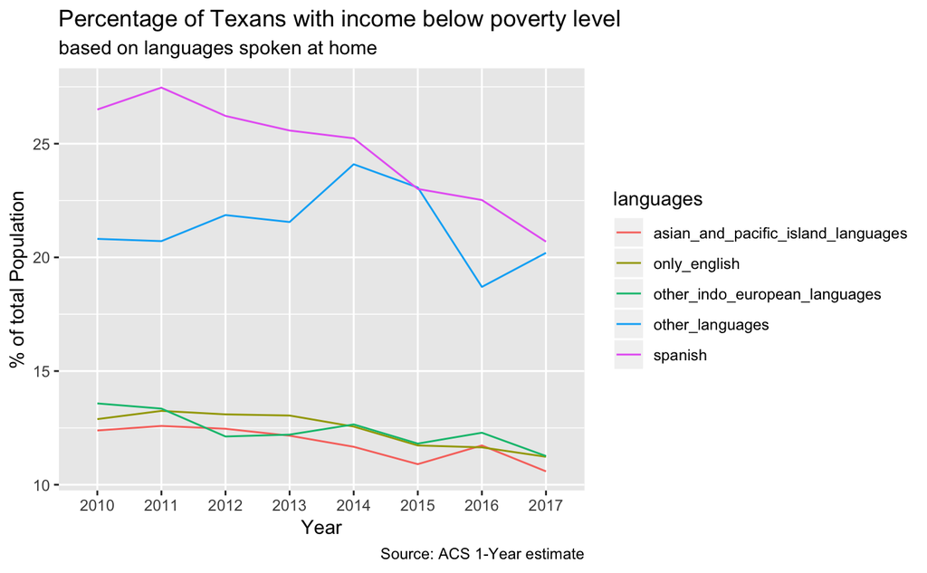

```r
above_below_pct %>%
  ggplot(aes(x = year, y = pct_below, group = languages)) +
  geom_line(aes(color = languages)) +
  labs(title = "Percentage of Texans with income below poverty level", subtitle = "based on languages spoken at home", caption = "Source: ACS 1-Year estimate", x = "Year", y = "% of total Population")
```

It seems that the % of the population living below poverty has declined in general for almost all groups. But here you can clearly see a gap between spanish speakers vs speakers of other language groups in terms of poverty.

There’s probably no use in plotting for above poverty because it’ll just be reversed.

```r
#exporting to use later
above_below_pct %>% saveRDS("data-out/above_below_pct.rds")
```

# Are my questions for this dataset answered?

- What is the percentage of people above and below poverty for each language group? -sort of answered. But I’ll create waffle charts to better illustrate this in the next notebook.
- Is there a larger share of people below poverty within a certain language group? -Yes. Spanish speakers.
- Is there a change overtime? -yes. poverty has generally declined.

More questions: * Are Spanish speakers “more likely to be in poverty” or are people below poverty level more likely to be Spanish speakers?

Who should I contact? - Nelson Flores, a professor at the University of Pennsylvania’s Graduate School of Education - NPR article (https://www.npr.org/sections/ed/2017/09/15/545629043/research-shows-spanish-speakers-take-longer-to-learn-english-why) - Donald Hernandez https://cdlc.uncg.edu/wp-content/uploads/2012/12/Hernandez-etal-2009-School-age-children-in-immigrant-families.txt